# results

#load packages and data

```r
library(ggplot2) #for plotting
library(broom) #for cleaning up output from lm()
library(here) #for data loading/saving
library(tidymodels) #for modeling
library(gridExtra) #for exporting tables
library(gridExtra) #for savings images in grids
library(dplyr)

mp <- readRDS(here("data", "processed_data", "mpwrfcombo.rds"))
sampledata <- readRDS(here("data", "processed_data", "fullsampledata.rds"))
```

# find CV for first three sample dates (within subject A -> B)

```r
sample_three <- sampledata %>% filter(!date == "july_21") # remove July samples (counted by volunteers, not by self)

sample <- sample_three %>% select(a_count, b_count)
matrix_sample <- data.matrix(sample)

sample <- sample %>% mutate(cv = (Rfast::rowcvs(matrix_sample, ln = FALSE)*100))

mean(sample$cv)
```

```
## [1] 26.95249
```

```r
median(sample$cv)
```

```
## [1] 20.20305
```

Woah - CVs for samples counted by me personally are averaging 20 - 26 for CV%. This is quite different from the volunteer counts. What does this say about the precision of volunteer counted-data?

# CV vs MP concentration

```r
# this was performed in the Barrows paper - looks at how variation correlates with concentration - previous findings showed that high-concentration sites had less variability among replicates

# create dataframe for all sites with CV values and concentration values
# average A and C and B and D counts so that they can be compared to the other sample dates for variation
avg_cd <- sampledata %>% filter(date == "july_21") %>% mutate(a_count = ((a_count+c_count)/2)) %>% mutate(b_count = ((b_count+d_count/2)))

# combine averaged july data with other three seasons of data
all_counts_cv <- full_join(avg_cd, sample_three)
# keep only useful variables
all_counts_part <- all_counts_cv %>% select(a_count, b_count, particles_l, date)
all_counts_cv <- all_counts_cv %>% select(a_count, b_count) # don't include particles/L so it won't be calculated with CV

# create matrix
all_counts_matrix <- data.matrix(all_counts_cv)
# mutate new variable to add CV
all_counts_cv <- all_counts_cv %>% mutate(cv = (Rfast::rowcvs(all_counts_matrix, ln = FALSE)*100))
# add MP concentration back in using join
all_counts_cv <- left_join(all_counts_cv, all_counts_part)
```

# plot MP concentration vs CV

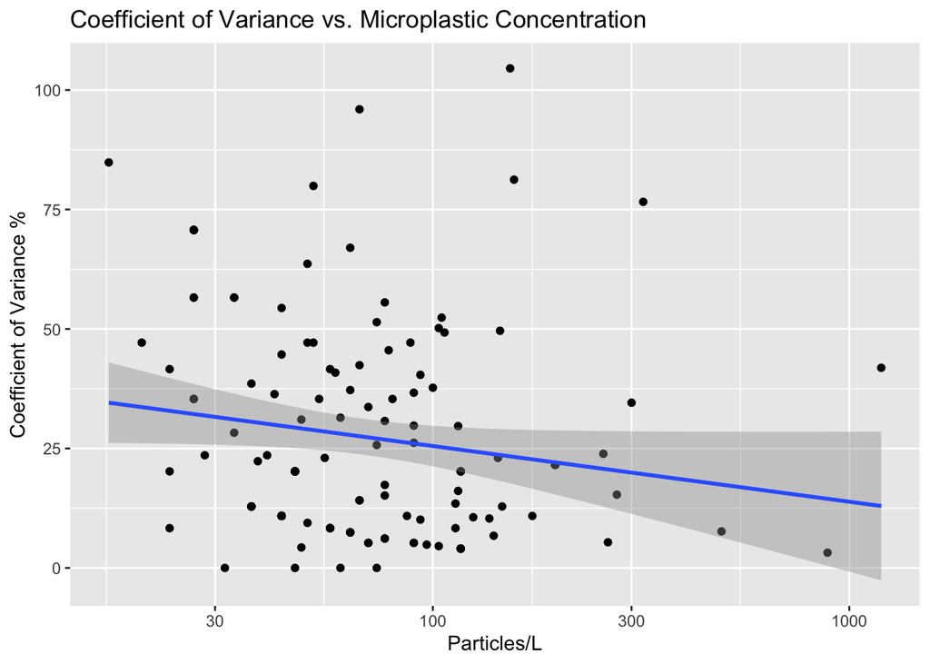

```r
ggplot(all_counts_cv, aes(x = particles_l, y = cv)) + geom_point() + geom_smooth(method = lm) + labs(title = "Coefficient of Variance vs. Microplastic Concentration ", x = "Particles/L", y = "Coefficient of Variance %") + scale_x_continuous(trans='log10') # use log scale to better visualize all points
```

Wonder if I can make this graph and have point colors correlate to sample dates. That would be interesting # Adding color to graph

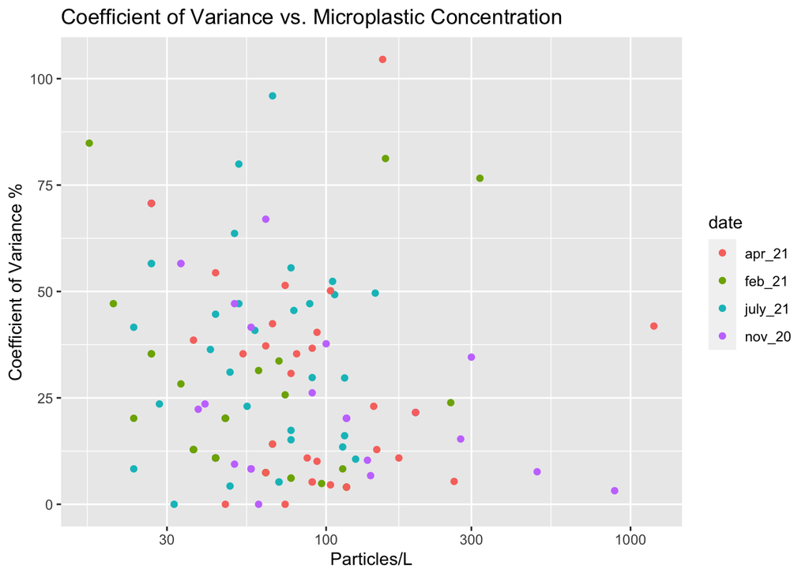

```r
ggplot(all_counts_cv, aes(x = particles_l, y = cv, color = date)) + geom_point() + labs(title = "Coefficient of Variance vs. Microplastic Concentration ", x = "Particles/L", y = "Coefficient of Variance %") + scale_x_continuous(trans='log10') # use log scale to better visualize all points
```

There appears to be a negative correlation between CV and microplastic concentration, which is consistent with what’s reported in the Barrows paper

## Next, let’s do a Kruskal Wallis test (basically a non-parametic one-way ANOVA, that considers more than two groups)

```r
kruskal.test(particles_l ~ date, data = all_counts_cv)
```

```
##
##  Kruskal-Wallis rank sum test
##
## data:  particles_l by date
## Kruskal-Wallis chi-squared = 14.181, df = 3, p-value = 0.002669
```

P=value less than 0.05 - we conclude that there IS a significant difference between groups (though we don’t yet know between what groups). From here, we may use the pairwise.wilcox.test() to calculate pairwise comparison # pairwise wilcox test to see differences between groups

```r
pairwise.wilcox.test(all_counts_cv$particles_l, all_counts_cv$date,
                 p.adjust.method = "BH")
```

```
##
##  Pairwise comparisons using Wilcoxon rank sum test with continuity correction
##
## data:  all_counts_cv$particles_l and all_counts_cv$date
##
##         apr_21 feb_21 july_21
## feb_21  0.0023 -      -
## july_21 0.0550 0.1900 -
## nov_20  0.2351 0.0648 0.3473
##
## P value adjustment method: BH
```

The only significant difference is between April and February sample dates. (in Barrows, March had the highest concentration)

Could perform regression analysis to compare original samples and corresponding duplicates over 1 year study period (using this language from the Barrows paper) (or does this mean between A and B duplicates?) Let’s try # linear regression for duplicates over study period

```r
#linear regression model specification set up
lm_mod <- linear_reg() %>% set_engine("lm")
#estimating/training linear model
lm_fit_dup <- lm_mod %>% fit(a_count ~ b_count, data = all_counts_cv)
#save table
lm_fit_dup_table <- tidy(lm_fit_dup)
#view summary of fit
(lm_fit_dup)
```

```
## parsnip model object
##
## Fit time:  4ms
##
## Call:
## stats::lm(formula = a_count ~ b_count, data = data)
##
## Coefficients:
## (Intercept)      b_count
##      -3.628        1.261
```

```r
summary(lm_fit_dup)
```

```
##         Length Class      Mode
## lvl      0     -none-     NULL
## spec     5     linear_reg list
## fit     12     lm         list
## preproc  1     -none-     list
## elapsed  5     proc_time  numeric
```

```r
#save file
saveRDS(lm_fit_dup_table, file = here("results", "lm_fit_dup_table.rds"))

model = lm(a_count ~ b_count, data = all_counts_cv)
summary(model)
```

```
##
## Call:
## lm(formula = a_count ~ b_count, data = all_counts_cv)
##
## Residuals:
##     Min      1Q  Median      3Q     Max
## -26.426  -3.767   0.800   2.539  76.724
##
## Coefficients:
##             Estimate Std. Error t value Pr(>|t|)
## (Intercept) -3.62763    1.29747  -2.796  0.00593 **
## b_count      1.26114    0.05725  22.029  < 2e-16 ***
## ---
## Signif. codes:  0 '***' 0.001 '**' 0.01 '*' 0.05 '.' 0.1 ' ' 1
##
## Residual standard error: 11.4 on 135 degrees of freedom
## Multiple R-squared:  0.7824, Adjusted R-squared:  0.7807
## F-statistic: 485.3 on 1 and 135 DF,  p-value: < 2.2e-16
```

p-value is <0.05 and multiple r-squared value is 0.7824 p-value indicates that the model reflects a signficant relationship r-squared is “degree to which the data is explained by the model” –> 78% of variability is explained by the model

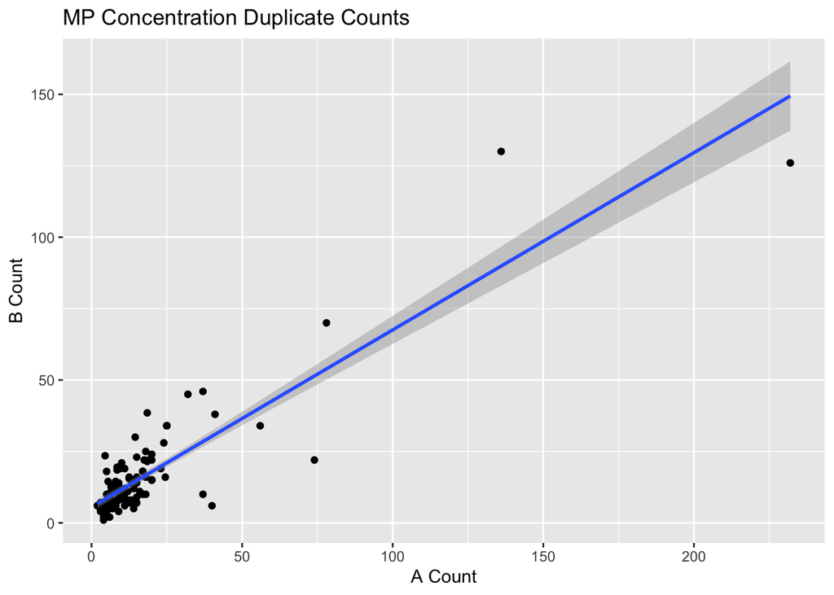

```r
#visualize linear model
lm_dup <- ggplot(all_counts_cv, aes(x = a_count, y = b_count)) + geom_point() + geom_smooth(method = lm) + labs(title = "MP Concentration Duplicate Counts", x = "A Count", y = "B Count")
lm_dup
```

It appears that the duplicate counts are pretty well correlated.

# want to test for significant difference within a group to see if sites are signficantly different/if the distribution of MP concentrations is signficant

```r
kruskal.test(particles_l ~ site, data = sampledata)
```

```
##
##  Kruskal-Wallis rank sum test
##
## data:  particles_l by site
## Kruskal-Wallis chi-squared = 33.01, df = 35, p-value = 0.5645
```

Seen in Barrows paper - other researchers found concentrations at 70 - 100 particles/L

Try to make plot to compare sites over seasons

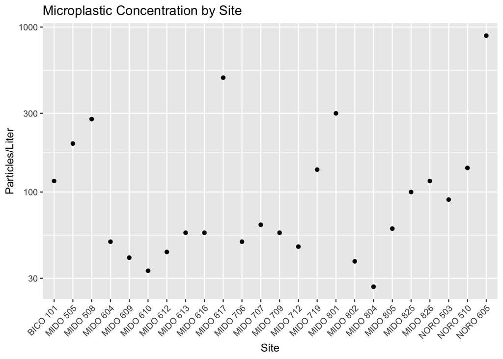

```r
sampledata %>% filter(date == "nov_20") %>% ggplot(aes(x = site, y = particles_l, color = )) +
  geom_point()  +
  theme(axis.text.x = element_text(angle = 45, hjust=1)) +
  labs(title = "Microplastic Concentration by Site", x = "Site", y = "Particles/Liter") + ylim(0,500) + scale_y_continuous(trans='log10')
```

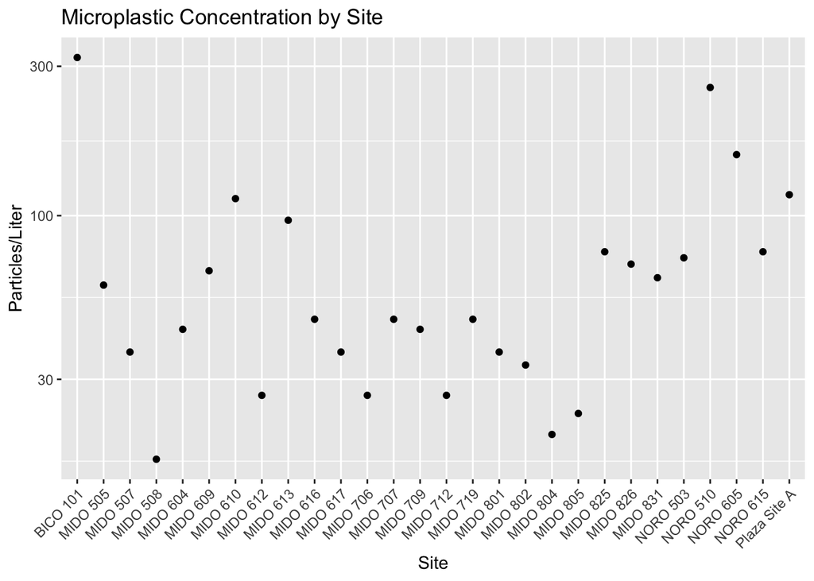

```r
# feb 2021
sampledata %>% filter(date == "feb_21") %>% ggplot(aes(x = site, y = particles_l, color = )) +
  geom_point()  +
  theme(axis.text.x = element_text(angle = 45, hjust=1)) +
  labs(title = "Microplastic Concentration by Site", x = "Site", y = "Particles/Liter") + ylim(0,500) + scale_y_continuous(trans='log10')
```

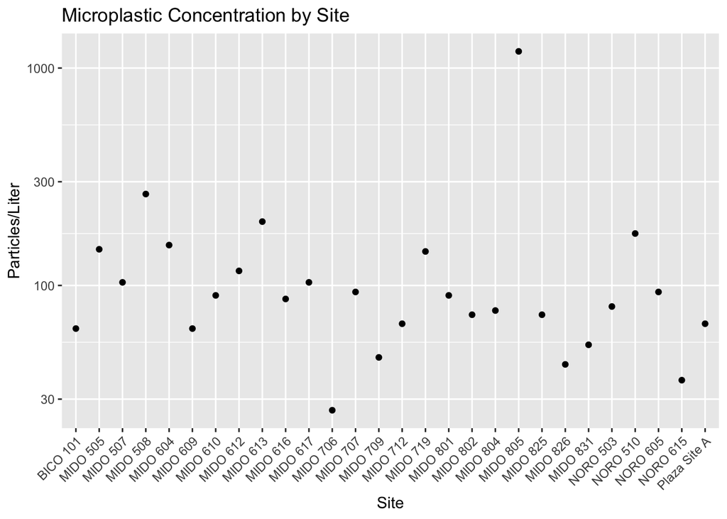

```r
# april 2021
sampledata %>% filter(date == "apr_21") %>% ggplot(aes(x = site, y = particles_l, color = )) +
  geom_point()  +
  theme(axis.text.x = element_text(angle = 45, hjust=1)) +
  labs(title = "Microplastic Concentration by Site", x = "Site", y = "Particles/Liter") + ylim(0,500) + scale_y_continuous(trans='log10')
```

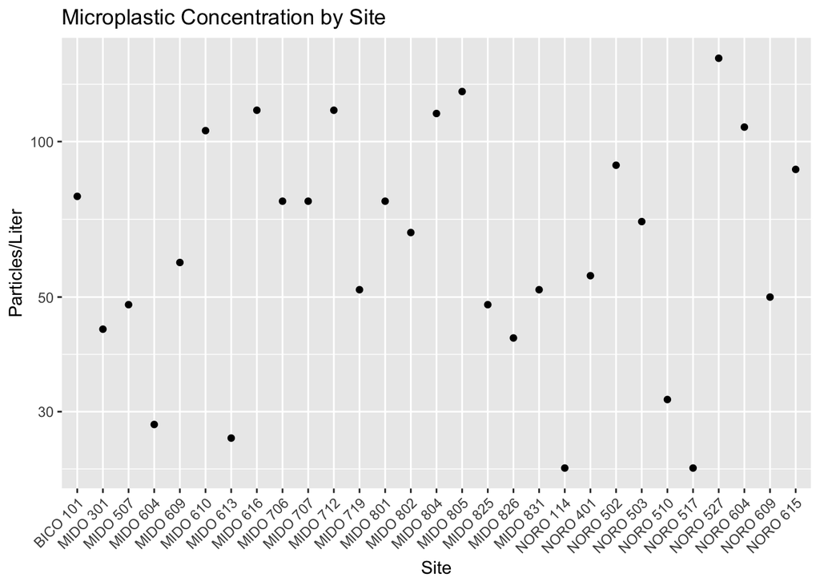

```r
# july 2021
sampledata %>% filter(date == "july_21") %>% ggplot(aes(x = site, y = particles_l, color = )) +
  geom_point()  +
  theme(axis.text.x = element_text(angle = 45, hjust=1)) +
  labs(title = "Microplastic Concentration by Site", x = "Site", y = "Particles/Liter") + ylim(0,500) + scale_y_continuous(trans='log10')
```

It could be interesting to have a table listing all of the site, and the concentration for each sample date in columns to the side. this might be easier to interpret than a graph for this type of data.

```r
table <- sampledata %>% select(particles_l, site, date)

table %>% rowwise()
```

```
## # A tibble: 109 × 3
## # Rowwise:
##    particles_l site     date
##          <dbl> <chr>    <chr>
##  1       197.  MIDO 505 nov_20
##  2       277.  MIDO 508 nov_20
##  3        50   MIDO 604 nov_20
##  4        43.3 MIDO 612 nov_20
##  5        33.3 MIDO 610 nov_20
##  6        56.7 MIDO 616 nov_20
##  7        40   MIDO 609 nov_20
##  8        56.7 MIDO 613 nov_20
##  9       493.  MIDO 617 nov_20
## 10        50   MIDO 706 nov_20
## # … with 99 more rows
```

```r
reshape(sampledata, idvar = "site", timevar = "date", direction = "wide")
```

```
## # A tibble: 36 × 14
##    site     `watershed.c("no… `lat.c("nov_20"… `long.c("nov_20… `volume_ml.c("n…
##    <chr>    <chr>                        <dbl>            <dbl>            <dbl>
##  1 MIDO 505 <NA>                            NA               NA               NA
##  2 MIDO 508 <NA>                            NA               NA               NA
##  3 MIDO 604 <NA>                            NA               NA               NA
##  4 MIDO 612 <NA>                            NA               NA               NA
##  5 MIDO 610 <NA>                            NA               NA               NA
##  6 MIDO 616 <NA>                            NA               NA               NA
##  7 MIDO 609 <NA>                            NA               NA               NA
##  8 MIDO 613 <NA>                            NA               NA               NA
##  9 MIDO 617 <NA>                            NA               NA               NA
## 10 MIDO 706 <NA>                            NA               NA               NA
## # … with 26 more rows, and 9 more variables:
## #   a_count.c("nov_20", "feb_21", "apr_21", "july_21") <dbl>,
## #   b_count.c("nov_20", "feb_21", "apr_21", "july_21") <dbl>,
## #   particles_l.c("nov_20", "feb_21", "apr_21", "july_21") <dbl>,
## #   obs_type.c("nov_20", "feb_21", "apr_21", "july_21") <chr>,
## #   id.c("nov_20", "feb_21", "apr_21", "july_21") <chr>,
## #   id2.c("nov_20", "feb_21", "apr_21", "july_21") <chr>, …
```

```r
table$date <- factor(table$date , levels=c("nov_20", "feb_21", "apr_21", "july_21")) #reorder dates to appear chronologically
# transform to wide data
data_wide <- spread(table, date, particles_l)
data_wide #display new data
```

```
## # A tibble: 36 × 5
##    site     nov_20 feb_21 apr_21 july_21
##    <chr>     <dbl>  <dbl>  <dbl>   <dbl>
##  1 BICO 101  117.   320     63.3    78.3
##  2 MIDO 301   NA     NA     NA      43.3
##  3 MIDO 505  197.    60    147.     NA
##  4 MIDO 507   NA     36.7  103.     48.3
##  5 MIDO 508  277.    16.7  263.     NA
##  6 MIDO 604   50     43.3  153.     28.3
##  7 MIDO 609   40     66.7   63.3    58.3
##  8 MIDO 610   33.3  113.    90     105
##  9 MIDO 612   43.3   26.7  117.     NA
## 10 MIDO 613   56.7   96.7  197.     26.7
## # … with 26 more rows
```

```r
# display decimal places upto 1
data_wide$nov_20<-format(round(data_wide$nov_20,1),nsmall=1)
data_wide$feb_21<-format(round(data_wide$feb_21,1),nsmall=1)
data_wide$apr_21<-format(round(data_wide$apr_21,1),nsmall=1)
data_wide$july_21<-format(round(data_wide$july_21,1),nsmall=1)
```